# The three perspectives demonstrated on a toy example

Andreas Scheidegger, Sandrine Charles, Roman Ashauer, Nele Schuwirth

28 January, 2026

## Notes

- Supporting information for the paper: “Three Perspectives on Model Building and Calibration for Ecological Risk Assessment” by Schuwirth, Ashauer, Baity-Jesi, Charles, Galic, Moor, Preziosi, Scheidegger, Schmolke & Strauss
- The dataset used is from Ashauer (2010).
- For simplicity of this didactical example, we use the limit of quantification (LOQ) divided by 2 for below-detection data, which is a common but not entirely correct approach.
- The priors are based on Hendriks et al. (2001).
- The code and input can be received from https://github.com/Eawag-SIAM/3-perspective-example

# Introduction

This example provides an analysis using a one-compartment toxicokinetic model. The data set used comes from *Gammarus pulex* exposed to Malathion, as reported by Ashauer (2010). The analysis explores three perspectives: using predefined parameters, performing maximum likelihood estimation (MLE), and incorporating Bayesian approaches to account for parameter uncertainty. This is a didactical toy example with the goal, to demonstrate the technical implementation of all three perspectives. It is not a realistic application case for perspectives 1 and 3. The results are not representative for typical use cases.

# Import Data

We load the data set containing measurements of internal concentrations in *Gammarus pulex* over time. The data set is visualized to understand the time course of internal concentrations. Unfortunately, we do not know which points belong to the same replicate.

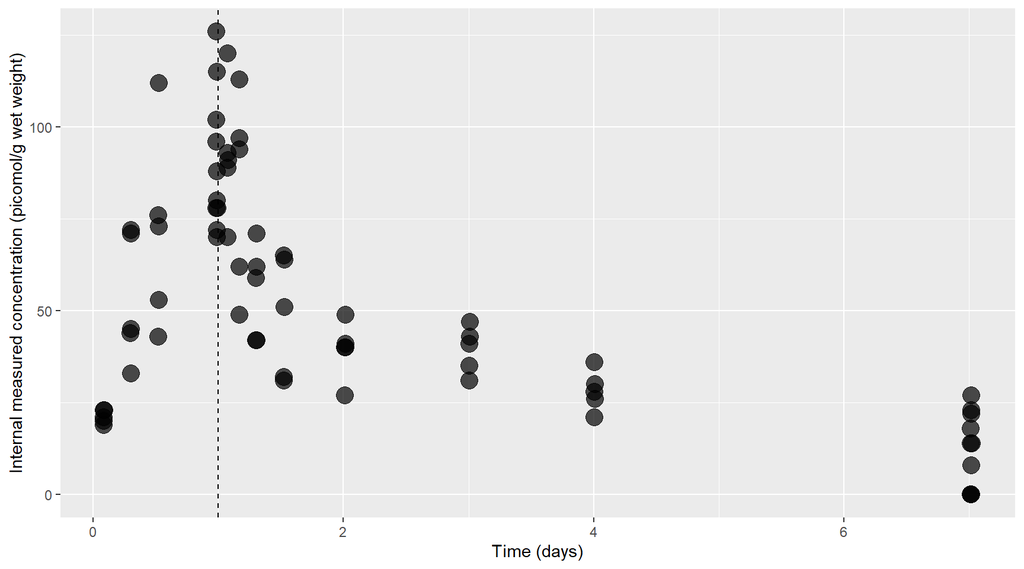

```r
df <- read.table("data/data_Malathion_Ashauer_2010.csv", header = TRUE, sep = ",")
df$sampling_date <- as.factor(df$sampling_date)

ggplot(data = df, aes(x = time, y = Cinternal)) +
  geom_point(size=5, alpha=0.7) +
  xlab("Time (days)") +
  ylab("Internal measured concentration (picomol/g wet weight)") +
  geom_vline(xintercept = 1, linetype="dashed")
```

We also define the limit of quantification (LOQ).

```r
## Limit of detection nmol/kg(wet weight)
## from Table 5 in SI of Ashauer et al. (2010)
LOQ <- 6
```

# Define Deterministic Model

We define a deterministic toxicokinetic model with two parameters: uptake rate ($k_u$) and elimination rate ($k_e$). This model predicts the internal concentration based on the exposure concentration in water and the simulation times. Note that the implementation assumes that `tsim` is ordered.

```r
bioacc <- function(parameters, C_water, tc, tsim){
  k.u <- parameters[1]
  k.e <- parameters[2]

  tacc <- tsim[tsim <= tc]
  Cacc <- k.u*C_water*(1 - exp(-k.e*tacc))/k.e

  tdep <- tsim[tsim > tc]
  Cdep <- k.u*C_water*(exp(k.e*(tc - tdep)) - exp(-k.e*tdep))/k.e

  result <- data.frame(time = c(tacc, tdep),
                       conc = c(Cacc, Cdep))
  return(result)
}
```

```r
C_water <- unique(df$Cwater)     # exposure concentration
tc <- 1                          # time until exposure ends [days]
```

### Helper Function

This function computes the 5%, 50%, and 95% intervals for each point in time using Monte Carlo simulations of the model output.

```r
compute.intervals <- function(X, tsim){
  intervals <-  t(apply(X, 2, function(x){quantile(x, probs=c(0.05, 0.5, 0.95))}))
  intervals <- as.data.frame(intervals)
  colnames(intervals) <- c("p05", "p50", "p95")
  intervals$time <- tsim
  intervals
}
```

# Perspective 1: Predefined Parameters

Using predefined parameters based on Hendriks et al. (2001), we run the model to predict internal concentrations and compare them to the observed data. We also sample parameter uncertainty and plot the 90% prediction interval. For the prior distribution, we assume lognormal distributions to ensure that the parameters can not be negative. They are defined by the mean and standard deviation of each parameter. Since we do not have prior knowledge about their correlation structure, we assume that the priors of the parameters are independent from each other. Since in this case the prior knowledge is vague, it results in large uncertainty intervals.

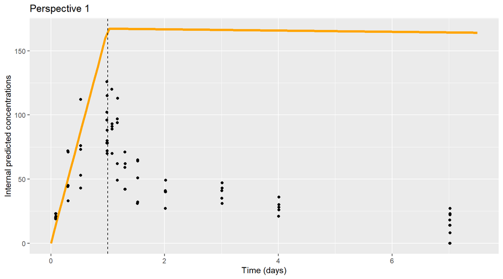

```r
parameters.P1 <- c(k.u = 112.798, k.e = 0.00296)

tsim <- seq(0, 7.5, length=111)
simu.mean.P1 <- bioacc(parameters.P1, C_water, tc, tsim)

ggplot(simu.mean.P1, aes(time, conc)) +
  geom_line(col = "orange", linewidth = 1.5) +
  xlab("Time (days)") +
  ylab("Internal predicted concentrations") +
  geom_vline(xintercept = 1, linetype="dashed") +
  geom_point(data = df, aes(time, Cinternal)) +
  ggtitle("Perspective 1")
```

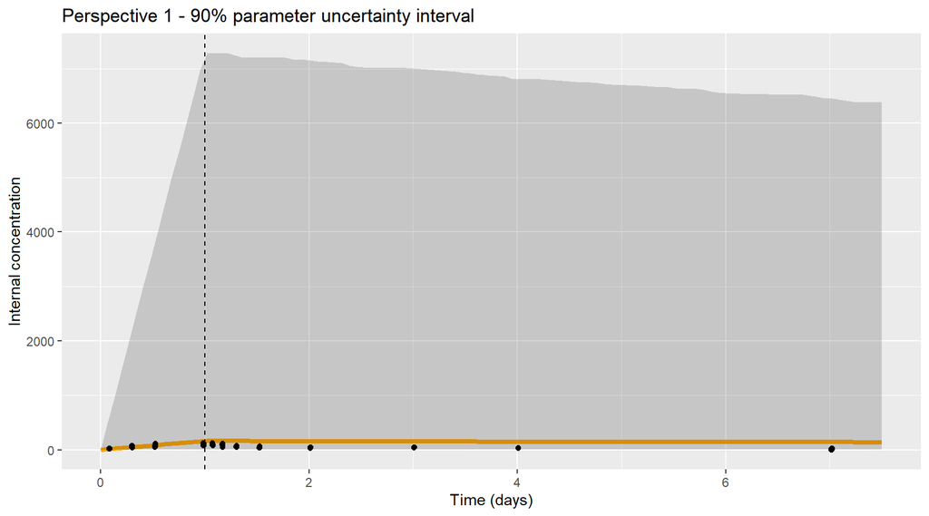

```r
n <- 10000
X.para <- matrix(NA, ncol=length(tsim), nrow=n)
for(i in 1:n){
  meanlog.k.u = log10(parameters.P1['k.u']) / log10(exp(1))
  meanlog.k.e = log10(parameters.P1['k.e']) / log10(exp(1))
  sdlog = log10(10) / log10(exp(1))
  para <- c(rlnorm(1, meanlog.k.u, sdlog),
            rlnorm(1, meanlog.k.e, sdlog))

  X.para[i,] <- bioacc(para, C_water, tc, tsim)$conc
}

intervals.para.P1 <- compute.intervals(X.para, tsim)

ggplot(intervals.para.P1) +
  geom_line(aes(x=time, y=p50), col = "orange", linewidth = 1.5) +
  geom_ribbon(aes(x=time, y=p50, ymin=p05, ymax=p95), alpha = 0.2) +
  xlab("Time (days)") +
  ylab("Internal concentration") +
  geom_vline(xintercept = 1, linetype="dashed") +
  geom_point(data = df, aes(time, Cinternal)) +
  ggtitle("Perspective 1 - 90% parameter uncertainty interval")
```

# Perspective 2: Maximum Likelihood Estimation

### *a) MLE with Normal-distributed errors

```r
log.ll.normal <- function(theta, data, LOQ=6) {
  conc.pred <- bioacc(theta, unique(data$Cwater), tc = 1, tsim = data$time)$conc
  obs <- ifelse(data$Cinternal==0, LOQ/2, data$Cinternal)
  sum(dnorm(obs, mean=conc.pred, sd=exp(theta[3]), log=TRUE))
}

mle <- maxLik::maxLik(log.ll.normal,
                      start = c(k.u=112, k.e=0.003, log.sd=log(1)),
                      data = df, LOQ = LOQ,
                      method = "NM")
summary(mle)
```

```
## --------------------------------------------
## Maximum Likelihood estimation
## Nelder-Mead maximization, 184 iterations
## Return code 0: successful convergence
## Log-Likelihood: -305.6714
## 3  free parameters
## Estimates:
##        Estimate Std. error t value Pr(> t)
## k.u    86.91052        NaN     NaN     NaN
## k.e     0.71693        NaN     NaN     NaN
## log.sd  2.94577    0.08435   34.92  <2e-16 ***
## ---
## Signif. codes:  0 '***' 0.001 '**' 0.01 '*' 0.05 '.' 0.1 ' ' 1
## --------------------------------------------
```

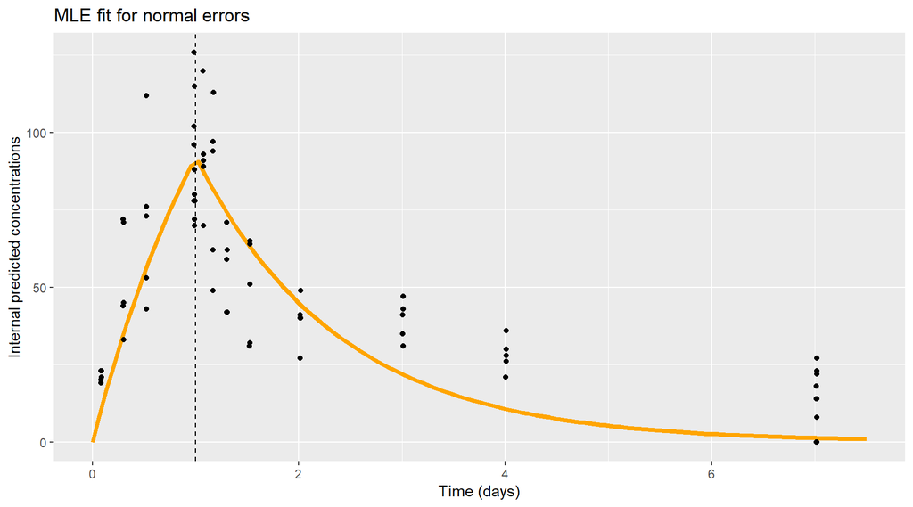

```r
parameters.P2.n <- mle$estimate
simu.mle.P2.n <- bioacc(parameters.P2.n, C_water, tc, tsim)

ggplot(simu.mle.P2.n, aes(time, conc)) +
  geom_line(col = "orange", linewidth = 1.5) +
  xlab("Time (days)") +
  ylab("Internal predicted concentrations") +
  geom_vline(xintercept = 1, linetype="dashed") +
  geom_point(data = df, aes(time, Cinternal)) +
  ggtitle("MLE fit for normal errors")
```

### *b) MLE with Gamma-distributed errors

We repeat the above process for gamma-distributed errors to avoid that concentrations can become negative.

```r
log.ll.gamma <- function(theta, data, LOQ=6) {
  mode <- bioacc(theta, unique(data$Cwater), tc = 1, tsim = data$time)$conc
  sd <- exp(theta[3])
  scale <- 0.5*(sqrt(4*sd^2+mode^2) - mode)
  shape <- mode/scale + 1
  obs <- ifelse(data$Cinternal==0, LOQ/2, data$Cinternal)
  sum(dgamma(obs, shape=shape, scale=scale, log=TRUE))
}

mle.g <- maxLik::maxLik(log.ll.gamma,
                        start = c(k.u=112, k.e=0.003, log.sd=log(1)),
                        data = df, LOQ = LOQ,
                        method= "NM")
summary(mle.g)
```

[output not shown]

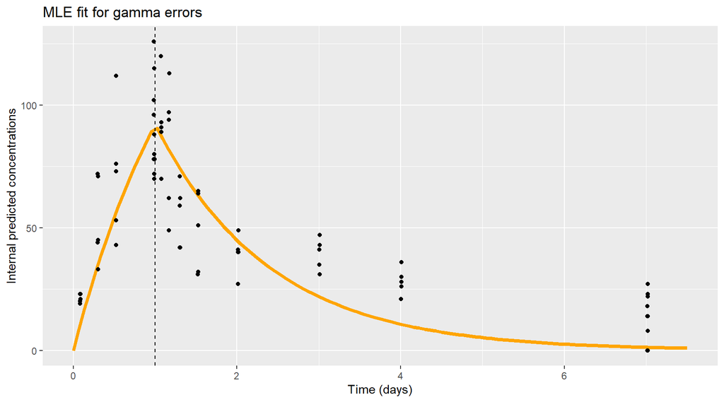

```r
parameters.P2.g <- mle$estimate
simu.mle.P2.g <- bioacc(parameters.P2.g, C_water, tc, tsim)

ggplot(simu.mle.P2.g, aes(time, conc)) +
  geom_line(col = "orange", linewidth = 1.5) +
  xlab("Time (days)") +
  ylab("Internal predicted concentrations") +
  geom_vline(xintercept = 1, linetype="dashed") +
  geom_point(data = df, aes(time, Cinternal)) +
  ggtitle("MLE fit for gamma errors")
```

## *Bootstrapping to propagate uncertainty

Maximum likelihood estimation computes confidence intervals for the parameters based on large-sample-size approximations. Bootstrapping avoids these approximations and also offers a straightforward way to propagate parameter uncertainty through the model to compute confidence intervals for predictions.

### *a) Normal-distributed errors

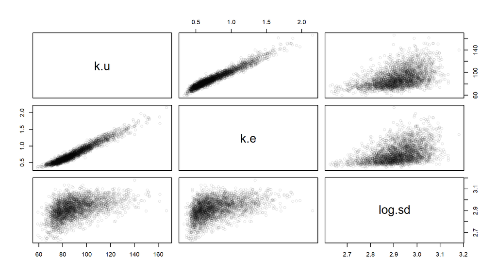

```r
# run non-parametric bootstrap

M <- 3000
thetas.boot <- matrix(NA, ncol=3, nrow=M)
colnames(thetas.boot) <- c("k.u", "k.e", "log.sd")
for(i in 1:M){
  idx <- sample(1:nrow(df), nrow(df), replace=TRUE)
  data.boot <- df[idx,]
  data.boot <- data.boot[order(data.boot$time),]
  fit <- maxLik::maxNM(log.ll.normal,
                       start = parameters.P2.n,
                       data = data.boot, LOQ = LOQ,
                       parscale = c(100, 1, 5))

  if(fit$code <= 2){ # check for convergence
    thetas.boot[i,] <- coef(fit)
  }
}

pairs(thetas.boot, col=gray(0, alpha=0.1))
```

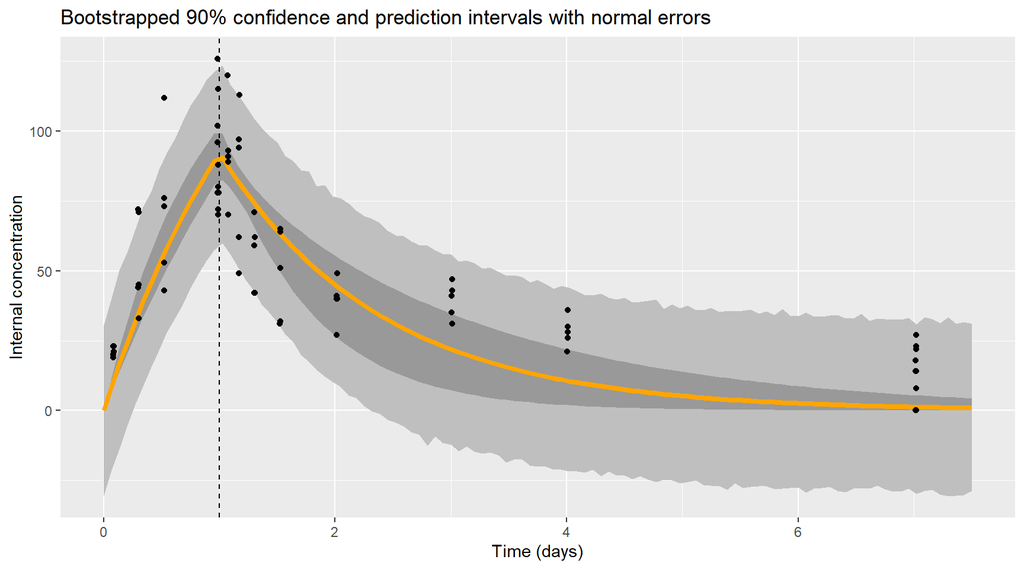

```r
## propagate parameters through models
X.para <- X.total <- matrix(NA, ncol=length(tsim), nrow=M)
for(i in 1:M){
  para <- thetas.boot[i,]
  X.para[i,] <- bioacc(para, C_water, tc, tsim)$conc
  sd <- exp(para[3])
  X.total[i,] <- rnorm(length(tsim), mean=X.para[i,], sd=sd)
}

intervals.para.P2.n <- compute.intervals(X.para, tsim)
intervals.total.P2.n <- compute.intervals(X.total, tsim)

ggplot() +
  geom_ribbon(data=intervals.total.P2.n, aes(x=time, y=p50, ymin=p05, ymax=p95), fill = gray(0.75)) +
  geom_ribbon(data=intervals.para.P2.n, aes(x=time, y=p50, ymin=p05, ymax=p95), fill = gray(0.6)) +
  geom_line(data = simu.mle.P2.n, aes(time, conc), col = "orange", linewidth = 1.5) +
  xlab("Time (days)") +
  ylab("Internal concentration") +
  geom_vline(xintercept = 1, linetype="dashed") +
  geom_point(data = df, aes(time, Cinternal)) +
  ggtitle("Bootstrapped 90% confidence and prediction intervals with normal errors")
```

### *b) Gamma-distributed errors

Again, we repeat the same procedure for the likelihood function based on the gamma distribution.

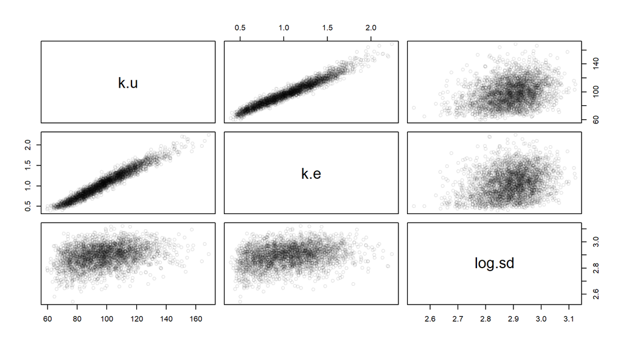

```r
# run non-parametric bootstrap

M <- 3000
thetas.boot.g <- matrix(NA, ncol=3, nrow=M)
colnames(thetas.boot.g) <- c("k.u", "k.e", "log.sd")
for(i in 1:M){
  idx <- sample(1:nrow(df), nrow(df), replace=TRUE)
  data.boot <- df[idx,]
  data.boot <- data.boot[order(data.boot$time),]
  fit <- maxLik::maxNM(log.ll.gamma,
                       start = parameters.P2.g,
                       data = data.boot, LOQ = LOQ,
                       parscale = c(100, 1, 5))

  if(fit$code <= 2){ #check for convergence
    thetas.boot.g[i,] <- coef(fit)
  }
}

pairs(thetas.boot.g, col=gray(0, alpha=0.1))
```

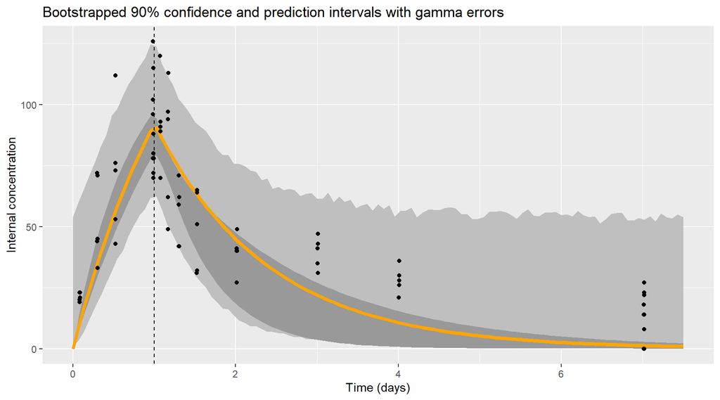

```r
## propagate parameters through models
X.para.g <- X.total.g <- matrix(NA, ncol=length(tsim), nrow=M)
for(i in 1:M){
  para <- thetas.boot.g[i,]
  X.para.g[i,] <- mode <- bioacc(para, C_water, tc, tsim)$conc
  sd <- exp(para[3])
  scale <- 0.5*(sqrt(4*sd^2+mode^2) - mode)
  shape <- mode/scale + 1
  X.total.g[i,] <- rgamma(length(tsim), scale=scale, shape=shape)
}

intervals.para.P2.g <- compute.intervals(X.para.g, tsim)
intervals.total.P2.g <- compute.intervals(X.total.g, tsim)

ggplot() +
  geom_ribbon(data=intervals.total.P2.g, aes(x=time, y=p50, ymin=p05, ymax=p95), fill = gray(0.75)) +
  geom_ribbon(data=intervals.para.P2.g, aes(x=time, y=p50, ymin=p05, ymax=p95), fill = gray(0.6)) +
  geom_line(data = simu.mle.P2.g, aes(time, conc), col = "orange", linewidth = 1.5) +
  xlab("Time (days)") +
  ylab("Internal concentration") +
  geom_vline(xintercept = 1, linetype="dashed") +
  geom_point(data = df, aes(time, Cinternal)) +
  ggtitle("Bootstrapped 90% confidence and prediction intervals with gamma errors")
```

# Perspective 3: Bayesian Inference

We incorporate prior knowledge into the model using a Bayesian approach, which allows us to sample from the posterior distribution of the parameters and estimate the uncertainty in our predictions.

## *Prior Definition

As in Perspective 1, the priors for the parameters are based on Hendriks et al. (2001).

```r
log.prior <- function(theta) {
  k.u <- 112.798
  k.e <- 0.00296

  meanlog.k.u = log10(k.u) / log10(exp(1))
  meanlog.k.e = log10(k.e) / log10(exp(1))
  sdlog = log10(10) / log10(exp(1))

  dlnorm(theta[1], meanlog.k.u, sdlog, log=TRUE) +
    dlnorm(theta[2], meanlog.k.e, sdlog, log=TRUE) +
    dnorm(theta[3], 2, 2, log=TRUE)
}
```

## *Posterior Distribution

We define functions proportional to the posterior distribution, incorporating both likelihood and prior information.

```r
log.post.normal <- function(theta, data, ...) {
  log.ll.normal(theta, data, ...) + log.prior(theta)
}

log.post.gamma <- function(theta, data, ...) {
  log.ll.gamma(theta, data, ...) + log.prior(theta)
}
```

## *MCMC Sampling

We sample from the posterior distribution using a Markov chain Monte Carlo (MCMC) method. This allows us quantify the uncertainty in the model predictions.

```r
pp.normal <- MCMC(log.post.normal, n=15000,
                  init = c(k.u=90, k.e=1, log.sd=2),
                  scale = c(100, 1, 1), acc.rate=0.2,
                  showProgressBar = FALSE,
                  data=df, LOQ = LOQ)
```

```
##   generate 15000 samples
```

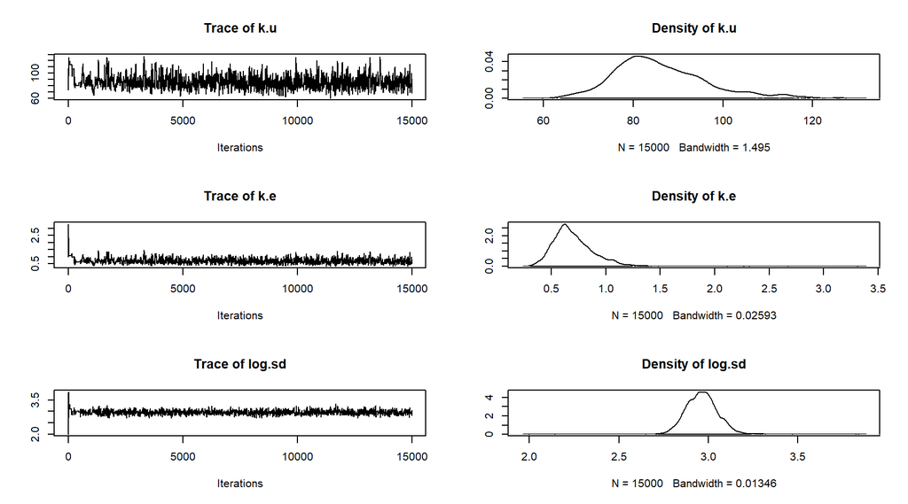

```r
post.normal <- convert.to.coda(pp.normal)

plot(post.normal)                              # whole chain
```

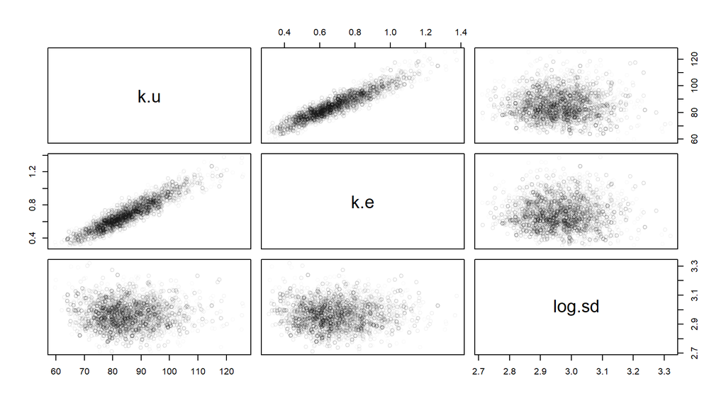

```r
pairs(pp.normal$samples[5000:15000,], col=gray(0, alpha=0.02))
```

```r
pp.gamma <- MCMC(log.post.gamma, n=15000,
                 init = c(k.u=90, k.e=1, log.sd=2),
                 scale = c(100, 1, 1),
                 showProgressBar = FALSE,
                 data=df, acc.rate=0.2)
```

```
##   generate 15000 samples
```

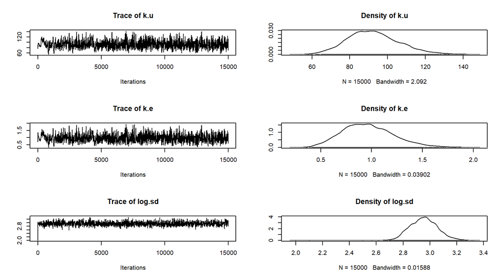

```r
post.gamma <- convert.to.coda(pp.gamma)

# get maximum posterior parameters and model results
map.index <- which(pp.gamma$log.p == max(pp.gamma$log.p))[1]
map.estimate <- pp.gamma$samples[map.index, ]
simu.map.P3.g <- bioacc(map.estimate, C_water, tc, tsim)

plot(post.gamma)                              # whole chain
```

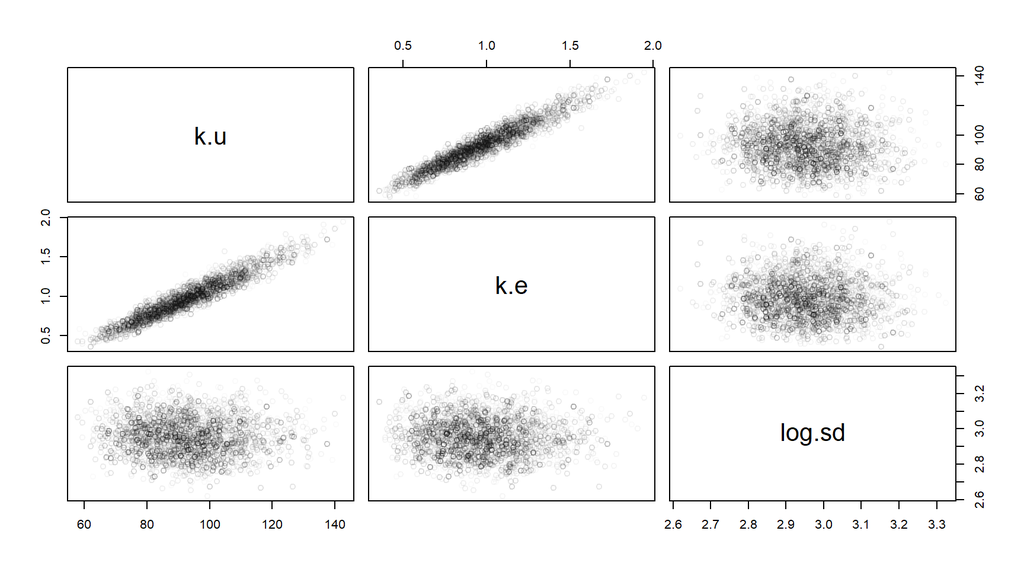

```r
pairs(pp.gamma$samples[5000:15000,], col=gray(0, alpha=0.02))
```

## *Credible and Posterior Prediction Intervals

Finally, we plot the 90% credible intervals for normal and gamma errors, incorporating both parameter and total uncertainty.

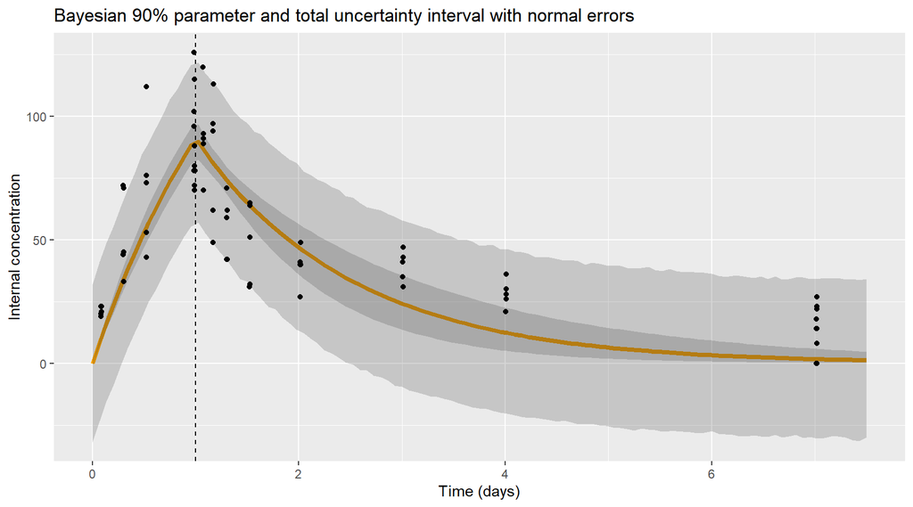

```r
n <- 10000
X.para <- X.total <- matrix(NA, ncol=length(tsim), nrow=n)
for(i in 1:n){
  idx <- sample(5000:15000, 1) # avoid the first 5000 burn-in samples
  para <- pp.normal$samples[idx,]
  X.para[i,] <- bioacc(para, C_water, tc, tsim)$conc
  sd <- exp(para[3])
  X.total[i,] <- rnorm(length(tsim), mean=X.para[i,], sd=sd)
}

intervals.para.P3.n <- compute.intervals(X.para, tsim)
intervals.total.P3.n <- compute.intervals(X.total, tsim)

ggplot(intervals.para.P3.n) +
  geom_line(aes(x=time, y=p50), col = "orange", linewidth = 1.5) +
  geom_ribbon(aes(x=time, y=p50, ymin=p05, ymax=p95), alpha = 0.2) +
  geom_ribbon(data=intervals.total.P3.n, aes(x=time, y=p50, ymin=p05, ymax=p95), alpha = 0.2) +
  xlab("Time (days)") +
  ylab("Internal concentration") +
  geom_vline(xintercept = 1, linetype="dashed") +
  geom_point(data = df, aes(time, Cinternal)) +
  ggtitle("Bayesian 90% parameter and total uncertainty interval with normal errors")
```

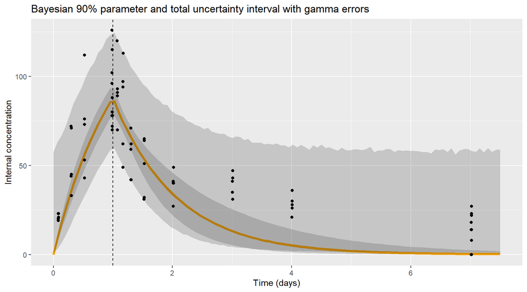

```r
n <- 10000
X.para <- X.total <- matrix(NA, ncol=length(tsim), nrow=n)
for(i in 1:n){
  idx <- sample(5000:15000, 1) # avoid the first 5000 burn-in samples
  para <- pp.gamma$samples[idx,]
  X.para[i,] <- mode <- bioacc(para, C_water, tc, tsim)$conc
  sd <- exp(para[3])
  scale <- 0.5*(sqrt(4*sd^2+mode^2) - mode)
  shape <- mode/scale + 1
  X.total[i,] <- rgamma(length(tsim), scale=scale, shape=shape)
}

intervals.para.P3.g <- compute.intervals(X.para, tsim)
intervals.total.P3.g <- compute.intervals(X.total, tsim)

ggplot(intervals.para.P3.g) +
  geom_line(aes(x=time, y=p50), col = "orange", linewidth = 1.5) +
  geom_ribbon(aes(x=time, y=p50, ymin=p05, ymax=p95), alpha = 0.2) +
  geom_ribbon(data=intervals.total.P3.g, aes(x=time, y=p50, ymin=p05, ymax=p95), alpha = 0.2) +
  xlab("Time (days)") +
  ylab("Internal concentration") +
  geom_vline(xintercept = 1, linetype="dashed") +
  geom_point(data = df, aes(time, Cinternal)) +
  ggtitle("Bayesian 90% parameter and total uncertainty interval with gamma errors")
```

# Compare Parameters

For Perspective 3, we can see how much we have learned from the data by comparing the Bayesian prior and the posterior distributions. Note that, strictly speaking, the bootstrap distribution from P2 cannot be directly compared to the prior. The prior represents (inter-)subjective prior knowledge, whereas the bootstrap reflects the distribution of the Frequentist estimator of the parameter. We show it here for illustration.

```r
## Define density of prior distributions for the parameters separately
k.u <- 112.798
meanlog.k.u <- log10(k.u) / log10(exp(1))

k.e <- 0.00296
meanlog.k.e <- log10(k.e) / log10(exp(1))

sdlog <- log10(10) / log10(exp(1))

d.ku <- function(theta) dlnorm(theta, meanlog.k.u, sdlog, log=F)
d.ke <- function(theta) dlnorm(theta, meanlog.k.e, sdlog, log=F)
```

### *a) Normal-distributed errors

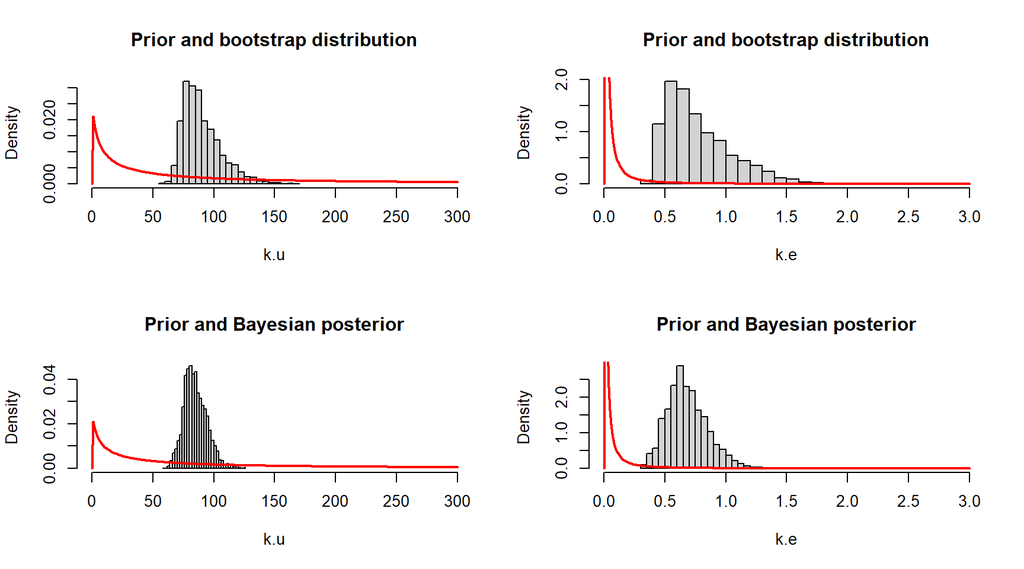

```r
par(mfrow=c(2,2))

ku.plt <- seq(0, 300, 1)
ke.plt <- seq(0, 3, 0.01)

## --- bootstrapping
hist(thetas.boot[,"k.u"], xlim=c(0, 300),
     xlab="k.u", main = "Prior and bootstrap distribution", probability = TRUE, breaks=25)
lines(ku.plt, d.ku(ku.plt), type="l", col="red", lwd=2)

hist(thetas.boot[,"k.e"],  xlim=c(0, 3),
     xlab="k.e", main = "Prior and bootstrap distribution", probability = TRUE, breaks=25)
lines(ke.plt, d.ke(ke.plt), type="l", col="red", lwd=2)


## --- Bayesian
hist(pp.normal$samples[5000:15000,"k.u"], xlim=c(0, 300),
     xlab="k.u", main = "Prior and Bayesian posterior", probability = TRUE, breaks=25)
lines(ku.plt, d.ku(ku.plt), type="l", col="red", lwd=2)

hist(pp.normal$samples[5000:15000,"k.e"],  xlim=c(0, 3),
     xlab="k.e", main = "Prior and Bayesian posterior", probability = TRUE, breaks=25)
lines(ke.plt, d.ke(ke.plt), type="l", col="red", lwd=2)
```

### *b) Gamma-distributed errors

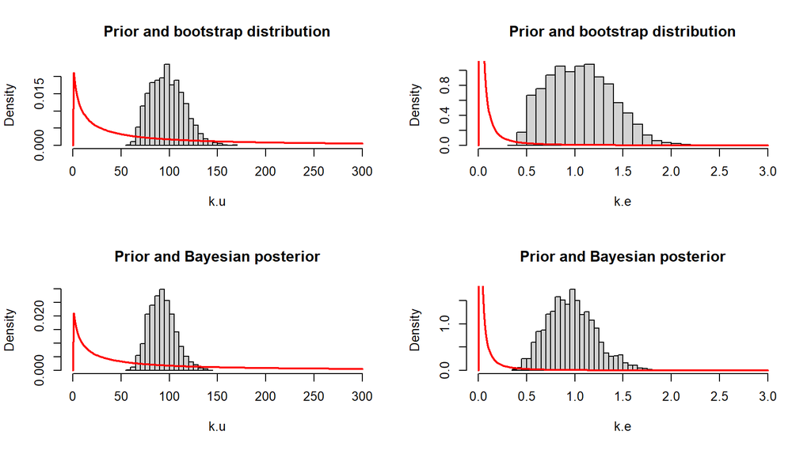

```r
par(mfrow=c(2,2))

ku.plt <- seq(0, 300, 1)
ke.plt <- seq(0, 3, 0.01)

## --- bootstrapping
hist(thetas.boot.g[,"k.u"], xlim=c(0, 300),
     xlab="k.u", main = "Prior and bootstrap distribution", probability = TRUE, breaks=25)
lines(ku.plt, d.ku(ku.plt), type="l", col="red", lwd=2)

hist(thetas.boot.g[,"k.e"],  xlim=c(0, 3),
     xlab="k.e", main = "Prior and bootstrap distribution", probability = TRUE, breaks=25)
lines(ke.plt, d.ke(ke.plt), type="l", col="red", lwd=2)


## --- bayes
hist(pp.gamma$samples[5000:15000,"k.u"], xlim=c(0, 300),
     xlab="k.u", main = "Prior and Bayesian posterior", probability = TRUE, breaks=25)
lines(ku.plt, d.ku(ku.plt), type="l", col="red", lwd=2)

hist(pp.gamma$samples[5000:15000,"k.e"],  xlim=c(0, 3),
     xlab="k.e", main = "Prior and Bayesian posterior", probability = TRUE, breaks=25)
lines(ke.plt, d.ke(ke.plt), type="l", col="red", lwd=2)
```

# Plots for paper

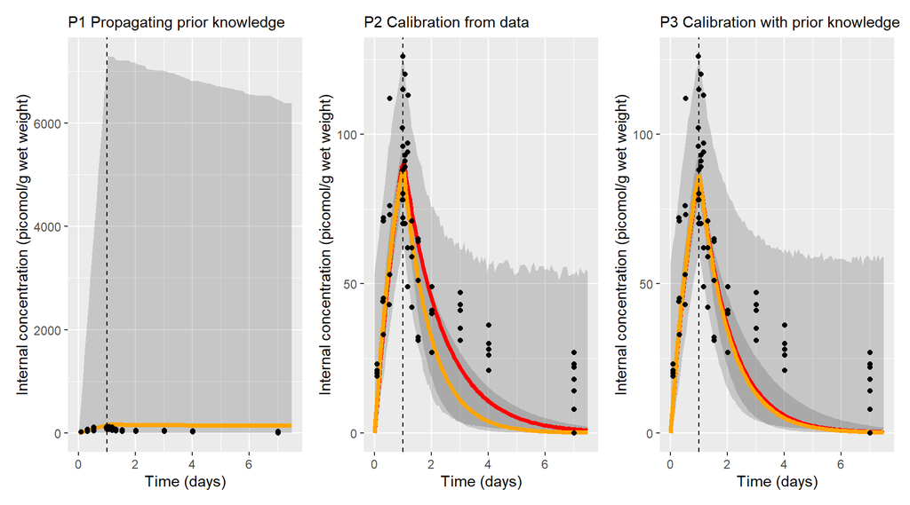

```r
# P1
P1 <- ggplot(intervals.para.P1) +
  geom_ribbon(aes(x=time, y=p50, ymin=p05, ymax=p95), alpha = 0.2) +
  geom_line(aes(x=time, y=p50), col = "orange", linewidth = 1.5) +
  xlab("Time (days)") +
  ylab("Internal concentration (picomol/g wet weight)") +
  geom_vline(xintercept = 1, linetype="dashed") +
  geom_point(data = df, aes(time, Cinternal)) +
  ggtitle("P1 Propagating prior knowledge") +
  theme(plot.title = element_text(size = 11))

# P2
P2 <- ggplot(intervals.para.P2.g) +
  geom_ribbon(aes(x=time, y=p50, ymin=p05, ymax=p95), alpha = 0.2) +
  geom_ribbon(data=intervals.total.P2.g, aes(x=time, y=p50, ymin=p05, ymax=p95), alpha = 0.2) +
  geom_line(data = simu.mle.P2.g, aes(time, conc), col = "red", linewidth = 1.5) +
  geom_line(aes(x=time, y=p50), col = "orange", linewidth = 1.5) +
  xlab("Time (days)") +
  ylab("Internal concentration (picomol/g wet weight)") +
  geom_vline(xintercept = 1, linetype="dashed") +
  geom_point(data = df, aes(time, Cinternal)) +
  ggtitle("P2 Calibration from data") +
  theme(plot.title = element_text(size = 11))

# P3
P3 <- ggplot(intervals.para.P3.g) +
  geom_ribbon(aes(x=time, y=p50, ymin=p05, ymax=p95), alpha = 0.2) +
  geom_ribbon(data=intervals.total.P3.g, aes(x=time, y=p50, ymin=p05, ymax=p95), alpha = 0.2) +
  geom_line(data = simu.map.P3.g, aes(time, conc), col = "red", linewidth = 1.5) +
  geom_line(aes(x=time, y=p50), col = "orange", linewidth = 1.5) +
  xlab("Time (days)") +
  ylab("Internal concentration (picomol/g wet weight)") +
  geom_vline(xintercept = 1, linetype="dashed") +
  geom_point(data = df, aes(time, Cinternal)) +
  ggtitle("P3 Calibration with prior knowledge") +
  theme(plot.title = element_text(size = 11))

combined_plot <- P1 | P2 | P3

combined_plot
```

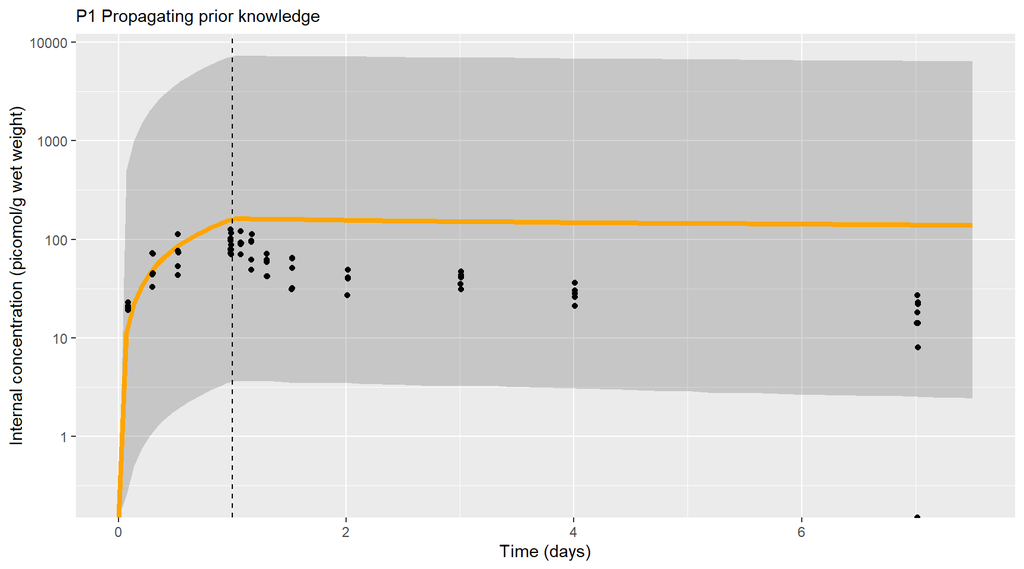

```r
P1+scale_y_log10()
```

```r
# Save to PDF
ggsave("Box1_Figure.pdf", combined_plot, width = 12, height = 4)
```

# References:

Ashauer, R., Caravatti, I., Hintermeister, A. & Escher, B.I. (2010). Bioaccumulation kinetics of organic xenobiotic pollutants in the freshwater invertebrate Gammarus pulex modeled with prediction intervals. Environmental Toxicology and Chemistry, 29, 1625-1636.

Hendriks, A.J., van der Linde, A., Cornelissen, G. & Sijm, D.T.H.M. (2001). The power of size. 1. Rate constants and equilibrium ratios for accumulation of organic substances related to octanol-water partition ratio and species weight. Environmental Toxicology and Chemistry, 20, 1399-1420.